# Análisis de Componentes Principales (PCA)

MSc. Darío Alvarado

El PCA es un método de estadística multivariada que se utiliza para reducir la dimensionalidad de los datos perdiendo la menor cantidad de información (varianza) posible (reduce el número de variables a X cantidad de componentes principales).

El PCA crea un nuevo set de variables ortogonales (no correlacionadas) que contienen la misma información que los datos originales. Sí el conjunto de datos originales tiene 10 variables, el PCA creará 10 componentes principales (nuevas variables) que no están correlacionadas. Se espera que los primeros componentes capturen la mayoría de la varianza de los datos y vaya decreciendo hacia los últimos componentes.

#### Paquetes

```r
library(tidyverse)
library(rio)
library(FactoMineR)
library(factoextra)
library(parameters)
library(ade4)
library(sjPlot)
```

### Contenido

#### Datos

Utilizaremos la base de datos “doubs” del paquete `ade4`. “doubs” es un conjunto de cuatro tablas de datos:

1. “env”: es una tabla de datos con 11 variables ambientales y 30 observaciones (sitios).
2. “fish”: es una tabla de datos de 27 especies de peces y 30 observaciones (sitios).
3. “xy”: es una tabla de datos con las coordenadas espaciales para los 30 sitios.
4. “species”: es una tabla de datos con cuatro columnas (nombres) y 27 filas (especies).

Para nuestro PCA trabajaremos con la tabla de datos “env”:

```r
data("doubs")
vars <- doubs$env # extraemos la tabla de datos de la base "doubs"
head(vars)
```

```
##   dfs alt   slo flo pH har pho nit amm oxy bdo
## 1   3 934 6.176  84 79  45   1  20   0 122  27
## 2  22 932 3.434 100 80  40   2  20  10 103  19
## 3 102 914 3.638 180 83  52   5  22   5 105  35
## 4 185 854 3.497 253 80  72  10  21   0 110  13
## 5 215 849 3.178 264 81  84  38  52  20  80  62
## 6 324 846 3.497 286 79  60  20  15   0 102  53
```

La tabla de datos de variables ambientales contiene las siguientes variables:

- “dfs”: distancia desde la fuente (km * 10)
- “alt”: altitud (m)
- “slo”: ln(x + 1) donde x es la pendiente (por mil * 100)
- “flo”: flujo de corriente promedio mínimo (m<sup>3</sup>/s * 100)
- “pH”: pH * 10
- “har”: dureza total del agua (Calcio en mg/L)
- “pho”: fosfatos (mg/L * 100)
- “nit”: nitratos (mg/L * 100)
- “amm”: nitrógeno amoniacal (mg/L * 100)
- “oxy”: oxígeno disuelto (mg/L * 10)
- “bdo”: demanda biológica de oxígeno (mg/L * 10)

#### PCA

Para realizar el análisis de componentes principales utilizamos la función `PCA()` del paquete `FactoMineR`:

```r
vars_pca <- PCA(vars,
                graph = FALSE) # para indicar que no muestre los gráficos
vars_pca
```

```
## **Results for the Principal Component Analysis (PCA)**
## The analysis was performed on 30 individuals, described by 11 variables
## *The results are available in the following objects:
##
##    name               description
## 1  "$eig"             "eigenvalues"
## 2  "$var"             "results for the variables"
## 3  "$var$coord"       "coord. for the variables"
## 4  "$var$cor"         "correlations variables - dimensions"
## 5  "$var$cos2"        "cos2 for the variables"
## 6  "$var$contrib"     "contributions of the variables"
## 7  "$ind"             "results for the individuals"
## 8  "$ind$coord"       "coord. for the individuals"
## 9  "$ind$cos2"        "cos2 for the individuals"
## 10 "$ind$contrib"     "contributions of the individuals"
## 11 "$call"            "summary statistics"
## 12 "$call$centre"     "mean of the variables"
## 13 "$call$ecart.type" "standard error of the variables"
## 14 "$call$row.w"      "weights for the individuals"
## 15 "$call$col.w"      "weights for the variables"
```

```r
# el resultado muestra qué información contiene nuestro PCA
```

Cuando las variables tienen unidades muy diferentes se puede hacer un escalado de esas variables con la función `scale()` y después hacer el PCA:

```r
vars_escalado <- scale(vars)
head(vars_escalado)
```

```
##         dfs      alt       slo       flo         pH        har        pho
## 1 -1.343374 1.667361 3.1639230 -1.180045 -0.8635475 -2.4369581 -0.6248726
## 2 -1.329769 1.659991 0.6259476 -1.171206 -0.2878492 -2.7334250 -0.6134629
## 3 -1.272483 1.593665 0.8147685 -1.127011  1.4392458 -2.0219044 -0.5792337
## 4 -1.213049 1.372579 0.6842599 -1.086684 -0.2878492 -0.8360367 -0.5221851
## 5 -1.191567 1.354155 0.3889958 -1.080607  0.2878492 -0.1245161 -0.2027128
## 6 -1.113515 1.343101 0.6842599 -1.068454 -0.8635475 -1.5475573 -0.4080878
##          nit         amm        oxy         bdo
## 1 -1.0287408 -0.55225131  1.2685942 -0.62541885
## 2 -1.0287408 -0.28843699  0.4108259 -0.83245406
## 3 -1.0145903 -0.42034415  0.5011173 -0.41838364
## 4 -1.0216655 -0.55225131  0.7268458 -0.98773046
## 5 -0.8023329 -0.02462267 -0.6275252  0.28036017
## 6 -1.0641170 -0.55225131  0.3656802  0.04744557
```

```r
vars_pca_scale <- PCA(vars_escalado,
                graph = FALSE)
vars_pca_scale
```

```
## **Results for the Principal Component Analysis (PCA)**
## The analysis was performed on 30 individuals, described by 11 variables
## *The results are available in the following objects:
##
##    name               description
## 1  "$eig"             "eigenvalues"
## 2  "$var"             "results for the variables"
## 3  "$var$coord"       "coord. for the variables"
## 4  "$var$cor"         "correlations variables - dimensions"
## 5  "$var$cos2"        "cos2 for the variables"
## 6  "$var$contrib"     "contributions of the variables"
## 7  "$ind"             "results for the individuals"
## 8  "$ind$coord"       "coord. for the individuals"
## 9  "$ind$cos2"        "cos2 for the individuals"
## 10 "$ind$contrib"     "contributions of the individuals"
## 11 "$call"            "summary statistics"
## 12 "$call$centre"     "mean of the variables"
## 13 "$call$ecart.type" "standard error of the variables"
## 14 "$call$row.w"      "weights for the individuals"
## 15 "$call$col.w"      "weights for the variables"
```

#### Revisión del PCA

Podemos hacer un `summary()` de todos los elementos que tiene nuestro PCA y el resutado nos mostrará los Eigenvalues, las 10 primeras observaciones (Individuals) que en este caso son los sitios, y las 10 primeras variables que en este caso son las variables ambientales:

```r
summary(vars_pca)
```

```
##
## Call:
## PCA(X = vars, graph = FALSE)
##
##
## Eigenvalues
##                        Dim.1   Dim.2   Dim.3   Dim.4   Dim.5   Dim.6   Dim.7
## Variance               6.322   2.232   1.004   0.501   0.375   0.248   0.166
## % of var.             57.469  20.287   9.129   4.552   3.411   2.254   1.513
## Cumulative % of var.  57.469  77.757  86.886  91.437  94.848  97.102  98.616
##                        Dim.8   Dim.9  Dim.10  Dim.11
## Variance               0.107   0.024   0.017   0.004
## % of var.              0.974   0.214   0.157   0.039
## Cumulative % of var.  99.590  99.804  99.961 100.000
##
## Individuals (the 10 first)
##         Dist    Dim.1    ctr   cos2    Dim.2    ctr   cos2    Dim.3    ctr
## 1   |  5.229 | -4.401 10.213  0.708 |  1.931  5.569  0.136 | -0.955  3.030
## 2   |  4.096 | -3.418  6.159  0.696 |  1.413  2.981  0.119 |  0.148  0.072
## 3   |  3.835 | -3.160  5.264  0.679 |  0.882  1.162  0.053 |  1.683  9.401
## 4   |  3.036 | -2.915  4.481  0.922 |  0.534  0.426  0.031 | -0.039  0.005
## 5   |  2.456 | -1.472  1.142  0.359 |  1.340  2.684  0.298 |  0.758  1.905
## 6   |  3.141 | -2.623  3.628  0.698 |  1.397  2.913  0.198 | -0.461  0.707
## 7   |  3.034 | -2.757  4.008  0.826 |  0.321  0.154  0.011 |  0.305  0.309
## 8   |  2.672 | -1.084  0.619  0.164 |  1.279  2.445  0.229 |  0.663  1.461
## 9   |  2.099 | -0.892  0.420  0.181 |  0.885  1.170  0.178 |  0.144  0.069
## 10  |  3.098 | -1.912  1.927  0.381 |  1.007  1.514  0.106 | -2.100 14.642
##       cos2
## 1    0.033 |
## 2    0.001 |
## 3    0.193 |
## 4    0.000 |
## 5    0.095 |
## 6    0.022 |
## 7    0.010 |
## 8    0.062 |
## 9    0.005 |
## 10   0.459 |
##
## Variables (the 10 first)
##        Dim.1    ctr   cos2    Dim.2    ctr   cos2    Dim.3    ctr   cos2
## dfs |  0.873 12.066  0.763 | -0.396  7.039  0.157 | -0.164  2.663  0.027 |
## alt | -0.839 11.137  0.704 |  0.454  9.227  0.206 |  0.130  1.681  0.017 |
## slo | -0.760  9.142  0.578 |  0.415  7.702  0.172 | -0.213  4.520  0.045 |
## flo |  0.778  9.569  0.605 | -0.504 11.371  0.254 | -0.191  3.640  0.037 |
## pH  | -0.025  0.010  0.001 | -0.376  6.322  0.141 |  0.913 83.065  0.834 |
## har |  0.712  8.026  0.507 | -0.401  7.210  0.161 | -0.034  0.114  0.001 |
## pho |  0.811 10.407  0.658 |  0.503 11.355  0.253 |  0.137  1.868  0.019 |
## nit |  0.902 12.857  0.813 |  0.107  0.510  0.011 |  0.011  0.013  0.000 |
## amm |  0.767  9.309  0.588 |  0.579 15.001  0.335 |  0.127  1.611  0.016 |
## oxy | -0.749  8.874  0.561 | -0.428  8.210  0.183 |  0.001  0.000  0.000 |
```

Y podemos extraer cada elemento por separado.

```r
vars_pca$eig
```

```
##          eigenvalue percentage of variance cumulative percentage of variance
## comp 1  6.321624098            57.46930998                          57.46931
## comp 2  2.231595827            20.28723479                          77.75654
## comp 3  1.004203842             9.12912584                          86.88567
## comp 4  0.500679947             4.55163588                          91.43731
## comp 5  0.375183255             3.41075686                          94.84806
## comp 6  0.247967596             2.25425087                          97.10231
## comp 7  0.166467787             1.51334352                          98.61566
## comp 8  0.107160713             0.97418830                          99.58985
## comp 9  0.023544131             0.21403756                          99.80388
## comp 10 0.017259075             0.15690069                          99.96078
## comp 11 0.004313729             0.03921572                         100.00000
```

#### Eigenvalues

**Eigenvalue** es la porción del total de la varianza que explica cada componente principal (dimensión). Como la tabla de datos tiene 11 variables ambientales, el PCA generó 11 componentes principales o dimensiones.

Los eigenvalues nos indican el porcentaje de varianza que explica cada componente principal, y también nos muestran el porcentaje acumulado de varianza. **Deberíamos quedarnos con los componentes que juntos expliquen el 70% de la varianza de forma acumulada.**

```r
vars_pca$eig
```

```
##          eigenvalue percentage of variance cumulative percentage of variance
## comp 1  6.321624098            57.46930998                          57.46931
## comp 2  2.231595827            20.28723479                          77.75654
## comp 3  1.004203842             9.12912584                          86.88567
## comp 4  0.500679947             4.55163588                          91.43731
## comp 5  0.375183255             3.41075686                          94.84806
## comp 6  0.247967596             2.25425087                          97.10231
## comp 7  0.166467787             1.51334352                          98.61566
## comp 8  0.107160713             0.97418830                          99.58985
## comp 9  0.023544131             0.21403756                          99.80388
## comp 10 0.017259075             0.15690069                          99.96078
## comp 11 0.004313729             0.03921572                         100.00000
```

Si observamos los valores del PCA con las variables escaladas notaremos que los valores son los mismos, ya que la variabilidad no se pierde al escalar los datos.

```r
vars_pca_scale$eig
```

```
##          eigenvalue percentage of variance cumulative percentage of variance
## comp 1  6.321624098            57.46930998                          57.46931
## comp 2  2.231595827            20.28723479                          77.75654
## comp 3  1.004203842             9.12912584                          86.88567
## comp 4  0.500679947             4.55163588                          91.43731
## comp 5  0.375183255             3.41075686                          94.84806
## comp 6  0.247967596             2.25425087                          97.10231
## comp 7  0.166467787             1.51334352                          98.61566
## comp 8  0.107160713             0.97418830                          99.58985
## comp 9  0.023544131             0.21403756                          99.80388
## comp 10 0.017259075             0.15690069                          99.96078
## comp 11 0.004313729             0.03921572                         100.00000
```

También podemos extraer los eigenvalues con la función `get_eigenvalue()` del paquete `factoextra`:

```r
get_eigenvalue(vars_pca)
```

```
##         eigenvalue variance.percent cumulative.variance.percent
## Dim.1  6.321624098      57.46930998                    57.46931
## Dim.2  2.231595827      20.28723479                    77.75654
## Dim.3  1.004203842       9.12912584                    86.88567
## Dim.4  0.500679947       4.55163588                    91.43731
## Dim.5  0.375183255       3.41075686                    94.84806
## Dim.6  0.247967596       2.25425087                    97.10231
## Dim.7  0.166467787       1.51334352                    98.61566
## Dim.8  0.107160713       0.97418830                    99.58985
## Dim.9  0.023544131       0.21403756                    99.80388
## Dim.10 0.017259075       0.15690069                    99.96078
## Dim.11 0.004313729       0.03921572                   100.00000
```

Podemos ver de forma gráfica el porcentaje de varianza que explica cada componente principal (CP) con la función `fviz_eig()` del paquete `factoextra`:

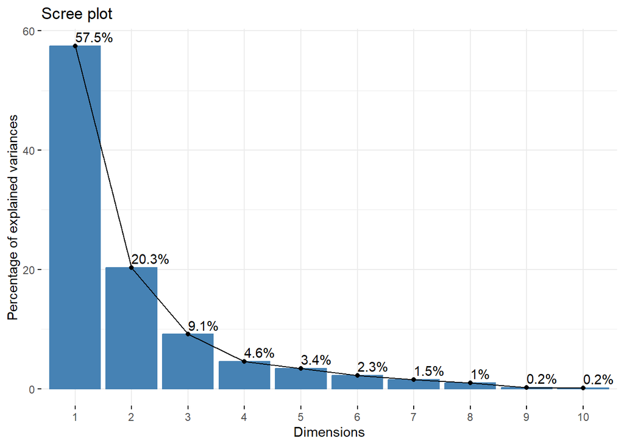

```r
fviz_eig(vars_pca,
         addlabels = TRUE)
```

El CP1 explica el 57.5% de la varianza, el CP2 explica el 20.3% de la varianza, juntos explican el 77.8% de la varianza acumulada.

#### Variables del PCA

Si extraemos las variables del PCA, el resultado nos muestra los valores para las coordenadas (“coord”), la correlación (“cor”), la representación (“cos2”) y la contribución (“contrib”) de cada variable para cada componente principal, por defecto se muestran solo los primeros cinco CPs.

```r
vars_pca$var
```

```
## $coord
##           Dim.1      Dim.2        Dim.3       Dim.4        Dim.5
## dfs  0.87335029 -0.3963445 -0.163535199  0.06395759 -0.125714631
## alt -0.83905354  0.4537709  0.129918288 -0.15163048 -0.050976207
## slo -0.76020468  0.4145874 -0.213039798  0.13158209  0.244375108
## flo  0.77776175 -0.5037445 -0.191181947  0.06629840 -0.063685383
## pH  -0.02457895 -0.3756069  0.913313669  0.03104019  0.010055431
## har  0.71229727 -0.4011204 -0.033804286 -0.35729968  0.439048518
## pho  0.81110560  0.5033806  0.136962677  0.14676897  0.110745297
## nit  0.90154907  0.1066847  0.011284133  0.31161854  0.001385844
## amm  0.76710859  0.5785809  0.127177507  0.17301992  0.088917093
## oxy -0.74899491 -0.4280275  0.001215206  0.38101962  0.277878554
## bdo  0.73752596  0.5985336  0.091096305 -0.17176324  0.052455661
##
## $cor
##           Dim.1      Dim.2        Dim.3       Dim.4        Dim.5
## dfs  0.87335029 -0.3963445 -0.163535199  0.06395759 -0.125714631
## alt -0.83905354  0.4537709  0.129918288 -0.15163048 -0.050976207
## slo -0.76020468  0.4145874 -0.213039798  0.13158209  0.244375108
## flo  0.77776175 -0.5037445 -0.191181947  0.06629840 -0.063685383
## pH  -0.02457895 -0.3756069  0.913313669  0.03104019  0.010055431
## har  0.71229727 -0.4011204 -0.033804286 -0.35729968  0.439048518
## pho  0.81110560  0.5033806  0.136962677  0.14676897  0.110745297
## nit  0.90154907  0.1066847  0.011284133  0.31161854  0.001385844
## amm  0.76710859  0.5785809  0.127177507  0.17301992  0.088917093
## oxy -0.74899491 -0.4280275  0.001215206  0.38101962  0.277878554
## bdo  0.73752596  0.5985336  0.091096305 -0.17176324  0.052455661
##
## $cos2
##            Dim.1      Dim.2        Dim.3        Dim.4        Dim.5
## dfs 0.7627407294 0.15708895 2.674376e-02 0.0040905739 1.580417e-02
## alt 0.7040108367 0.20590804 1.687876e-02 0.0229918035 2.598574e-03
## slo 0.5779111495 0.17188274 4.538596e-02 0.0173138455 5.971919e-02
## flo 0.6049133350 0.25375850 3.655054e-02 0.0043954782 4.055828e-03
## pH  0.0006041248 0.14108057 8.341419e-01 0.0009634934 1.011117e-04
## har 0.5073673958 0.16089758 1.142730e-03 0.1276630589 1.927636e-01
## pho 0.6578922955 0.25339198 1.875877e-02 0.0215411302 1.226452e-02
## nit 0.8127907240 0.01138162 1.273317e-04 0.0971061123 1.920564e-06
## amm 0.5884555921 0.33475585 1.617412e-02 0.0299358919 7.906249e-03
## oxy 0.5609933799 0.18320754 1.476725e-06 0.1451759488 7.721649e-02
## bdo 0.5439445355 0.35824246 8.298537e-03 0.0295026101 2.751596e-03
##
## $contrib
##            Dim.1      Dim.2        Dim.3      Dim.4        Dim.5
## dfs 12.065581844  7.0393100 2.663181e+00  0.8170037 4.212386e+00
## alt 11.136550129  9.2269413 1.680810e+00  4.5921159 6.926145e-01
## slo  9.141814516  7.7022343 4.519596e+00  3.4580665 1.591734e+01
## flo  9.568954522 11.3711677 3.639753e+00  0.8779018 1.081026e+00
## pH   0.009556482  6.3219591 8.306499e+01  0.1924370 2.694995e-02
## har  8.025902647  7.2099785 1.137946e-01 25.4979373 5.137852e+01
## pho 10.407013850 11.3547435 1.868025e+00  4.3023753 3.268941e+00
## nit 12.857308682  0.5100214 1.267986e-02 19.3948475 5.119003e-04
## amm  9.308614099 15.0007381 1.610641e+00  5.9790475 2.107303e+00
## oxy  8.874197060  8.2097099 1.470543e-04 28.9957586 2.058101e+01
## bdo  8.604506169 16.0531962 8.263797e-01  5.8925088 7.334006e-01
```

Los elementos de las variables que extraemos para utilizar nuestro PCA como nuestras nuevas variables en un modelo pueden ser las coordenadas o la correlación (tienen los mismos valores):

```r
variables <- data.frame(vars_pca$var$coord)
variables
```

```
##           Dim.1      Dim.2        Dim.3       Dim.4        Dim.5
## dfs  0.87335029 -0.3963445 -0.163535199  0.06395759 -0.125714631
## alt -0.83905354  0.4537709  0.129918288 -0.15163048 -0.050976207
## slo -0.76020468  0.4145874 -0.213039798  0.13158209  0.244375108
## flo  0.77776175 -0.5037445 -0.191181947  0.06629840 -0.063685383
## pH  -0.02457895 -0.3756069  0.913313669  0.03104019  0.010055431
## har  0.71229727 -0.4011204 -0.033804286 -0.35729968  0.439048518
## pho  0.81110560  0.5033806  0.136962677  0.14676897  0.110745297
## nit  0.90154907  0.1066847  0.011284133  0.31161854  0.001385844
## amm  0.76710859  0.5785809  0.127177507  0.17301992  0.088917093
## oxy -0.74899491 -0.4280275  0.001215206  0.38101962  0.277878554
## bdo  0.73752596  0.5985336  0.091096305 -0.17176324  0.052455661
```

Lo exportamos con la función `export()` del paquete `rio`:

```r
export(variables, "PCA_variables.csv")
```

Luego solo deberíamos seleccionar los CPs que expliquen el 70% de la varianza acumulada y colocar cada uno en un objeto separado:

```r
CP_vars <- select(variables, Dim.1, Dim.2)
CP_vars
```

```
##           Dim.1      Dim.2
## dfs  0.87335029 -0.3963445
## alt -0.83905354  0.4537709
## slo -0.76020468  0.4145874
## flo  0.77776175 -0.5037445
## pH  -0.02457895 -0.3756069
## har  0.71229727 -0.4011204
## pho  0.81110560  0.5033806
## nit  0.90154907  0.1066847
## amm  0.76710859  0.5785809
## oxy -0.74899491 -0.4280275
## bdo  0.73752596  0.5985336
```

Las coordenadas indican las coordenadas de cada variable en el espacio de componentes principales. Estas coordenadas representan la proyección de cada variable en el subespacio formado por los componentes principales y pueden utilizarse para visualizar la distribución de los datos y las relaciones entre las variables en el espacio reducido. En un gráfico de dispersión de coordenadas, las variables con coordenadas similares suelen ser similares en términos de su contribución a la varianza total explicada por los componentes principales.

##### Gráfico de correlación entre las variables de los CPs

Podemos generar un gráfico de coordenadas o de correlación de las variables con la función `fviz_pca_var()` del paquete `factoextra`:

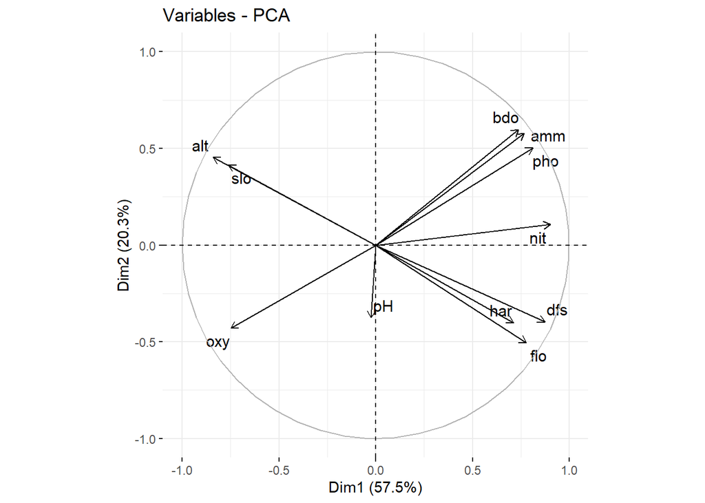

```r
fviz_pca_var(vars_pca,
             repel = TRUE) # para que las etiquetas de las variables no se traslapen
```

El gráfico muestra por defecto los CPs (dimensiones) 1 y 2, pero podemos especificar los componentes que queremos que se grafiquen con el argumento `axes = c(1,3)` (para que grafique los CPs 1 y 3).

- Las variables correlacionadas positivamente se agrupan juntas en el gráfico, por ejemplo “bdo”, “amm” y “pho” están correlacionadas positivamente.
- Las variables correlacionadas negativamente están en lados opuestos del gráfico, por ejemplo, las variables anteriores están correlacionadas negativamente con la variable “oxy”.
- Las flechas de mayor tamaño (desde el origen del gráfico hacia el borde de la circunferencia) indican una mejor representación de las variables en los CPs

##### Calidad de la representación de cada variable

```r
vars_pca$var$cos2
```

```
##            Dim.1      Dim.2        Dim.3        Dim.4        Dim.5
## dfs 0.7627407294 0.15708895 2.674376e-02 0.0040905739 1.580417e-02
## alt 0.7040108367 0.20590804 1.687876e-02 0.0229918035 2.598574e-03
## slo 0.5779111495 0.17188274 4.538596e-02 0.0173138455 5.971919e-02
## flo 0.6049133350 0.25375850 3.655054e-02 0.0043954782 4.055828e-03
## pH  0.0006041248 0.14108057 8.341419e-01 0.0009634934 1.011117e-04
## har 0.5073673958 0.16089758 1.142730e-03 0.1276630589 1.927636e-01
## pho 0.6578922955 0.25339198 1.875877e-02 0.0215411302 1.226452e-02
## nit 0.8127907240 0.01138162 1.273317e-04 0.0971061123 1.920564e-06
## amm 0.5884555921 0.33475585 1.617412e-02 0.0299358919 7.906249e-03
## oxy 0.5609933799 0.18320754 1.476725e-06 0.1451759488 7.721649e-02
## bdo 0.5439445355 0.35824246 8.298537e-03 0.0295026101 2.751596e-03
```

La calidad de la representación de cada variable para cada CP está basada en el “cos2” (coseno al cuadrado = coordenadas al cuadrado). Indica la proporción de la varianza total explicada por cada componente principal que está representada por cada variable y evalua la calidad de la representación de cada variable en el espacio de componentes principales. Un valor de “cos2” alto indica que una gran proporción de la varianza total está representada por una variable en particular, lo que puede indicar una alta importancia de esa variable para la estructura general del conjunto de datos.

Podemos ver la calidad de la representación de las variables con la función `fviz_cos2()` del paquete `factoextra` de forma individual para cada dimensión:

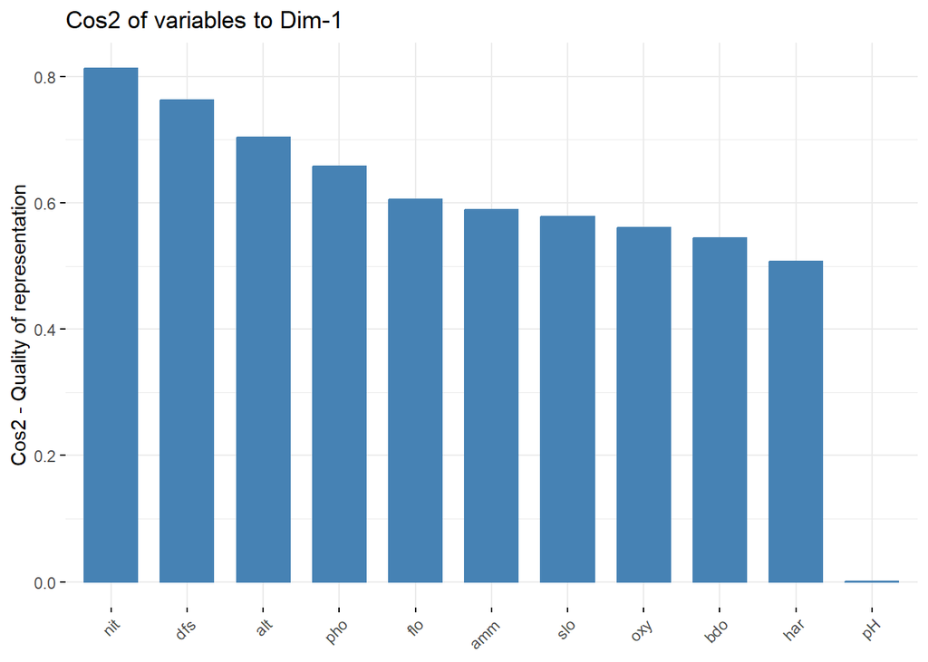

```r
fviz_cos2(vars_pca,
          choice = "var", # indicamos que es para las variables
          axes = 1) # indicamos el componente principal (dimensión)
```

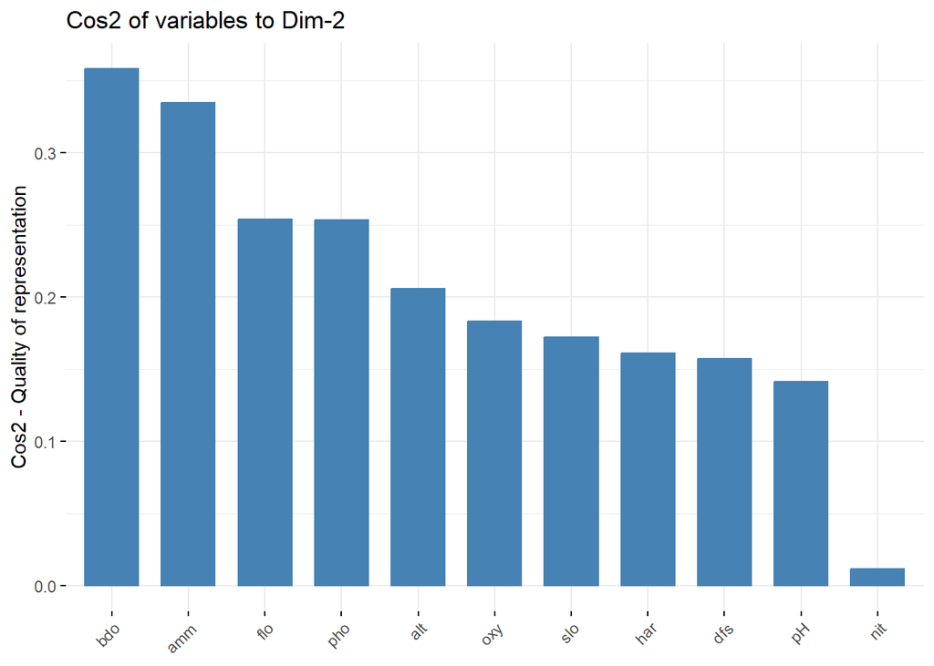

```r
fviz_cos2(vars_pca,
          choice = "var",
          axes = 2)
```

Y podemos hacerlo para más de un componente principal a la vez:

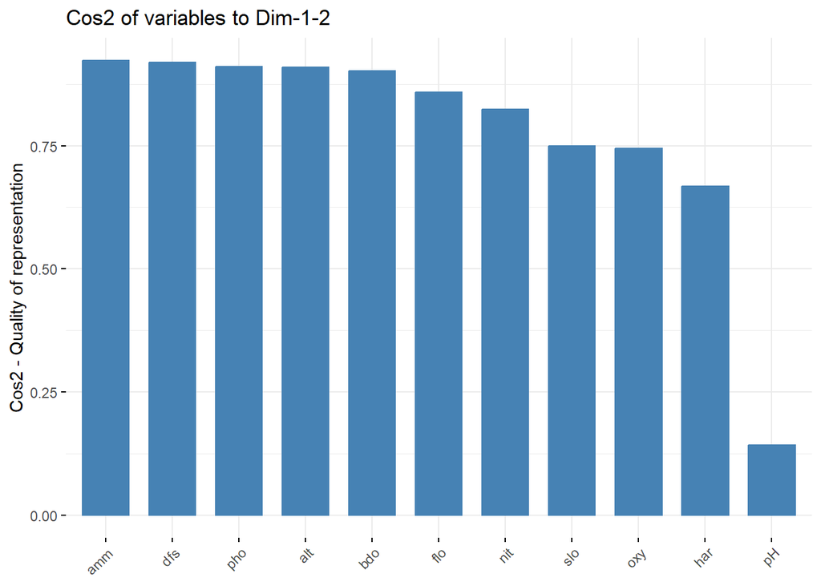

```r
fviz_cos2(vars_pca,
          choice = "var",
          axes = 1:2) # indicamos que queremos los dos componentes principales
```

También podemos hacer el gráfico de correlación en base a la calidad de representación de cada variable:

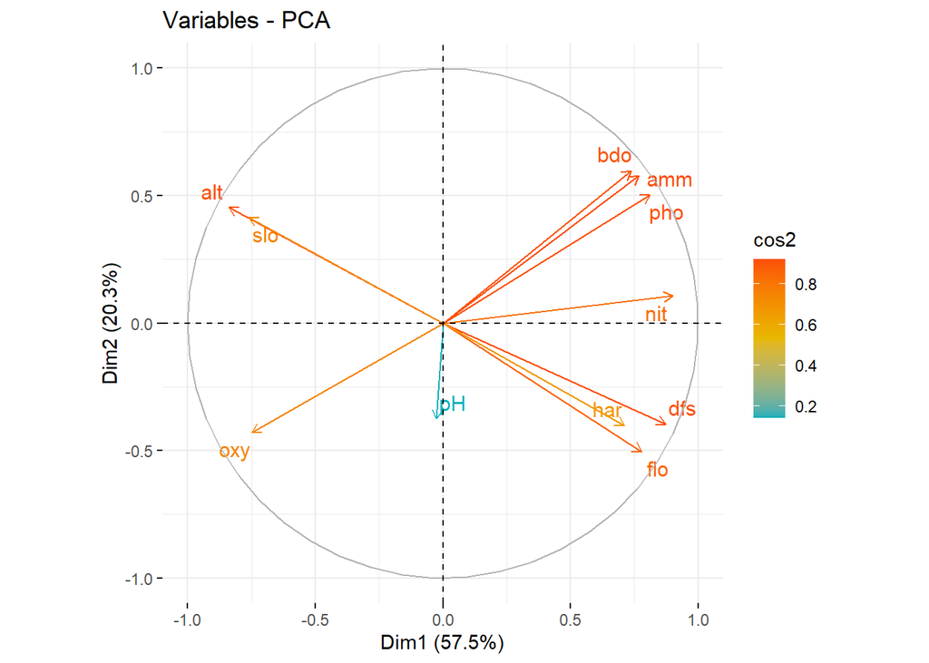

```r
fviz_pca_var(vars_pca,
             col.var = "cos2", # indicamos que el color de las variables esté basado en el "cos2"
             gradient.cols = c("#00AFBB", "#E7B800", "#FC4E07"), # indicamos un gradiente de color
             repel = TRUE)
```

Y podemos hacerlo en una escala de grises:

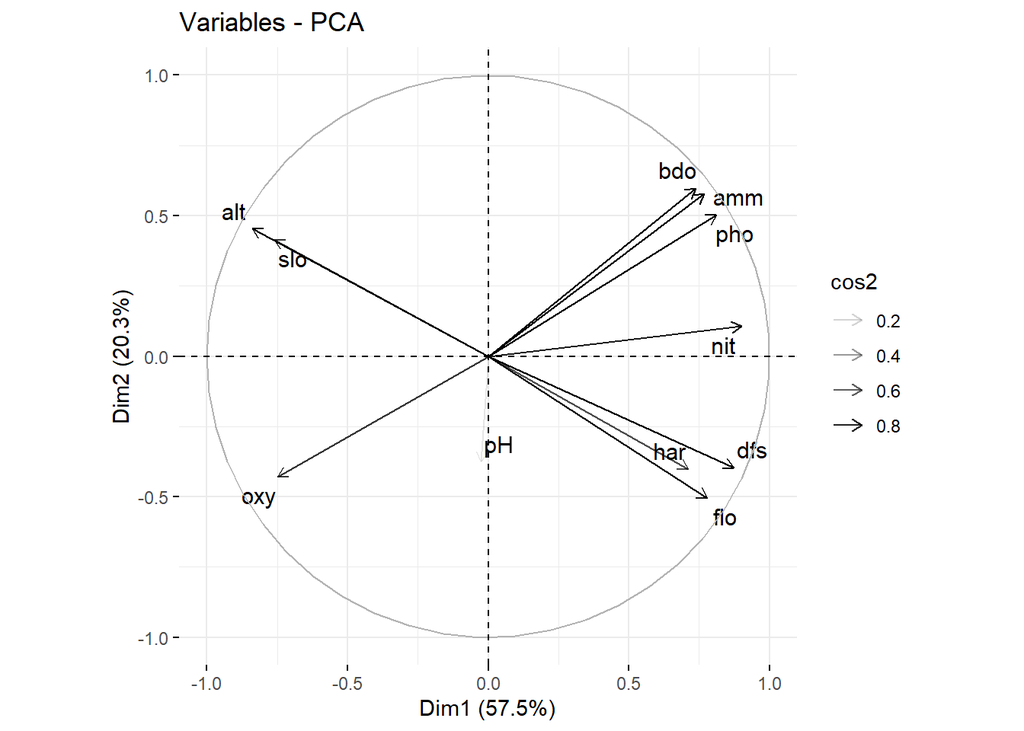

```r
fviz_pca_var(vars_pca,
             alpha.var = "cos2", # para que reduzca la intensidad del color basado en el "cos2"
             repel = TRUE)
```

##### Contribución de las variables a cada CP

```r
vars_pca$var$contrib
```

```
##            Dim.1      Dim.2        Dim.3      Dim.4        Dim.5
## dfs 12.065581844  7.0393100 2.663181e+00  0.8170037 4.212386e+00
## alt 11.136550129  9.2269413 1.680810e+00  4.5921159 6.926145e-01
## slo  9.141814516  7.7022343 4.519596e+00  3.4580665 1.591734e+01
## flo  9.568954522 11.3711677 3.639753e+00  0.8779018 1.081026e+00
## pH   0.009556482  6.3219591 8.306499e+01  0.1924370 2.694995e-02
## har  8.025902647  7.2099785 1.137946e-01 25.4979373 5.137852e+01
## pho 10.407013850 11.3547435 1.868025e+00  4.3023753 3.268941e+00
## nit 12.857308682  0.5100214 1.267986e-02 19.3948475 5.119003e-04
## amm  9.308614099 15.0007381 1.610641e+00  5.9790475 2.107303e+00
## oxy  8.874197060  8.2097099 1.470543e-04 28.9957586 2.058101e+01
## bdo  8.604506169 16.0531962 8.263797e-01  5.8925088 7.334006e-01
```

Podemos ver la contribución de las variables con la función `fviz_contrib()` del paquete `factoextra` de forma individual para cada dimensión:

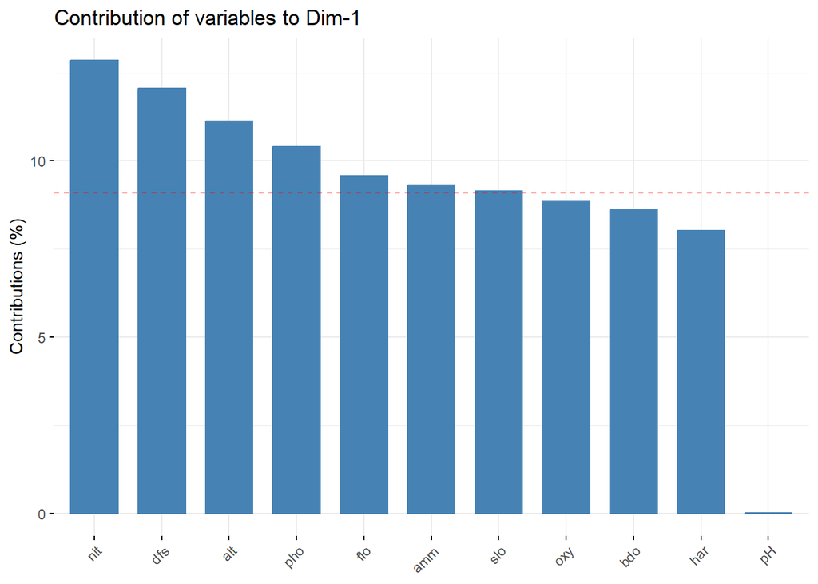

```r
fviz_contrib(vars_pca,
             choice = "var",
             axes = 1)
```

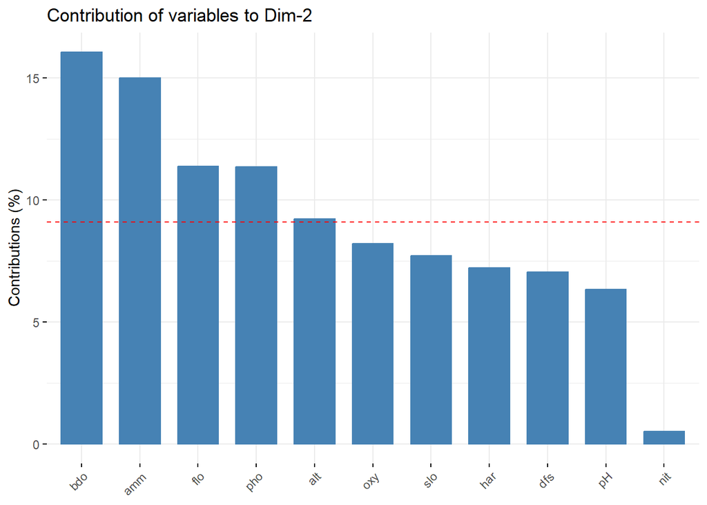

```r
fviz_contrib(vars_pca,
             choice = "var",
             axes = 2)
```

O para ambos CPs

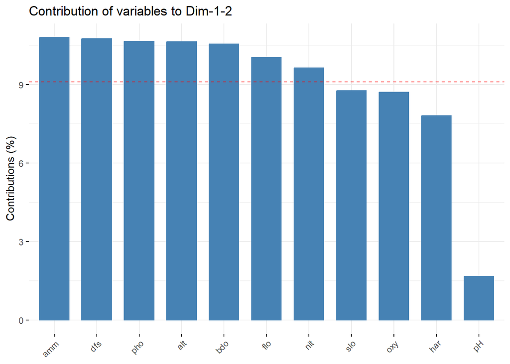

```r
fviz_contrib(vars_pca,
             choice = "var",
             axes = 1:2)
```

Y podemos realizar el gráfico de coordenadas basado en la contribución de las variables:

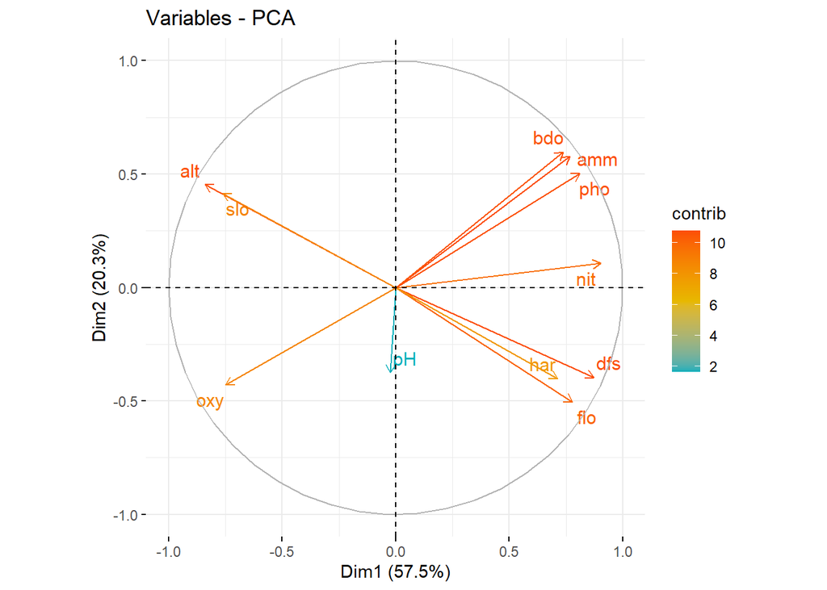

```r
fviz_pca_var(vars_pca,
             col.var = "contrib", # indicamos que el color de las variables sea basado en la contribución
             gradient.cols = c("#00AFBB", "#E7B800", "#FC4E07"),
             repel = TRUE)
```

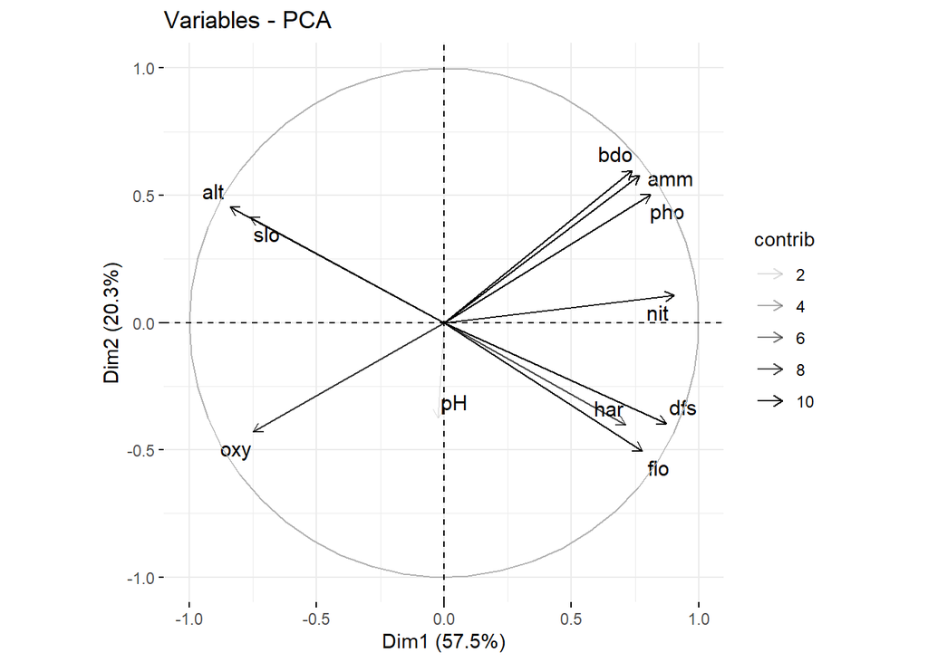

```r
fviz_pca_var(vars_pca,
             alpha.var = "contrib",
             repel = TRUE)
```

#### Individuals del PCA

Los individuals del PCA representan los datos para cada fila de la tabla de datos, en este caso, están representando a los 30 sitios donde se tomaron las mediciones de variables ambientales.

```r
vars_pca$ind
```

```
## $coord
##         Dim.1      Dim.2        Dim.3        Dim.4       Dim.5
## 1  -4.4009463  1.9308480 -0.955382771  1.331338438  0.08895638
## 2  -3.4177855  1.4126455  0.147724904  0.682307785 -1.52336725
## 3  -3.1597098  0.8820650  1.682927637  0.381559504 -0.84561819
## 4  -2.9150285  0.5341381 -0.038907190 -0.031478619 -0.01526196
## 5  -1.4719392  1.3404080  0.757617423 -1.178481769  0.01237619
## 6  -2.6231909  1.3965852 -0.461460299 -0.122752059 -0.61941071
## 7  -2.7570143  0.3210542  0.304913111 -0.404456558  0.96969432
## 8  -1.0838142  1.2793067  0.663350045 -1.911439750  0.22445870
## 9  -0.8922127  0.8850634  0.144037468 -1.483244852 -0.26036766
## 10 -1.9115201  1.0069306 -2.100231945 -0.207301526  0.56997716
## 11 -1.0747779 -0.6614165 -0.016680847  0.286832873  1.15970213
## 12 -1.3983300 -0.6862590 -0.939801947  0.135536684  0.45236306
## 13 -1.2580098 -1.2615841  0.002338985  0.000436717  1.10483864
```

[output cut: 93 more lines]

Los elementos de los individuals (sitios) del PCA son las coordenadas (“coord”), la representación de los sitios (“cos2”), la contribución (“contrib”) y la distancia (“dist”) que indica la distancia euclidiana entre cada observación (individuo; sitio) y el centro de masa de todas las observaciones en el espacio de componentes principales. Esta distancia puede utilizarse para identificar outliers u observaciones atípicas en el conjunto de datos.

Los elementos de los sitios que extraemos para utilizar nuestro PCA como nuestras nuevas variables en un modelo son las coordenadas:

```r
sitios <- data.frame(vars_pca$ind$coord)
sitios
```

```
##         Dim.1      Dim.2        Dim.3        Dim.4       Dim.5
## 1  -4.4009463  1.9308480 -0.955382771  1.331338438  0.08895638
## 2  -3.4177855  1.4126455  0.147724904  0.682307785 -1.52336725
## 3  -3.1597098  0.8820650  1.682927637  0.381559504 -0.84561819
## 4  -2.9150285  0.5341381 -0.038907190 -0.031478619 -0.01526196
## 5  -1.4719392  1.3404080  0.757617423 -1.178481769  0.01237619
## 6  -2.6231909  1.3965852 -0.461460299 -0.122752059 -0.61941071
## 7  -2.7570143  0.3210542  0.304913111 -0.404456558  0.96969432
## 8  -1.0838142  1.2793067  0.663350045 -1.911439750  0.22445870
## 9  -0.8922127  0.8850634  0.144037468 -1.483244852 -0.26036766
## 10 -1.9115201  1.0069306 -2.100231945 -0.207301526  0.56997716
## 11 -1.0747779 -0.6614165 -0.016680847  0.286832873  1.15970213
## 12 -1.3983300 -0.6862590 -0.939801947  0.135536684  0.45236306
## 13 -1.2580098 -1.2615841  0.002338985  0.000436717  1.10483864
## 14 -0.6926349 -1.4507791  1.228371456  0.140144968  0.97399781
```

[output cut: 16 more lines]

```r
export(sitios, "PCA_sitios.csv")
```

```r
CP_sitios <- select(sitios, Dim.1, Dim.2)
head(CP_sitios)
```

```
##       Dim.1     Dim.2
## 1 -4.400946 1.9308480
## 2 -3.417785 1.4126455
## 3 -3.159710 0.8820650
## 4 -2.915029 0.5341381
## 5 -1.471939 1.3404080
## 6 -2.623191 1.3965852
```

##### Gráfico de coordenadas de los sitios

Podemos generar el gráfico de corrdenadas para los sitios con la función `fviz_pca_ind()` del paquete `factoextra`:

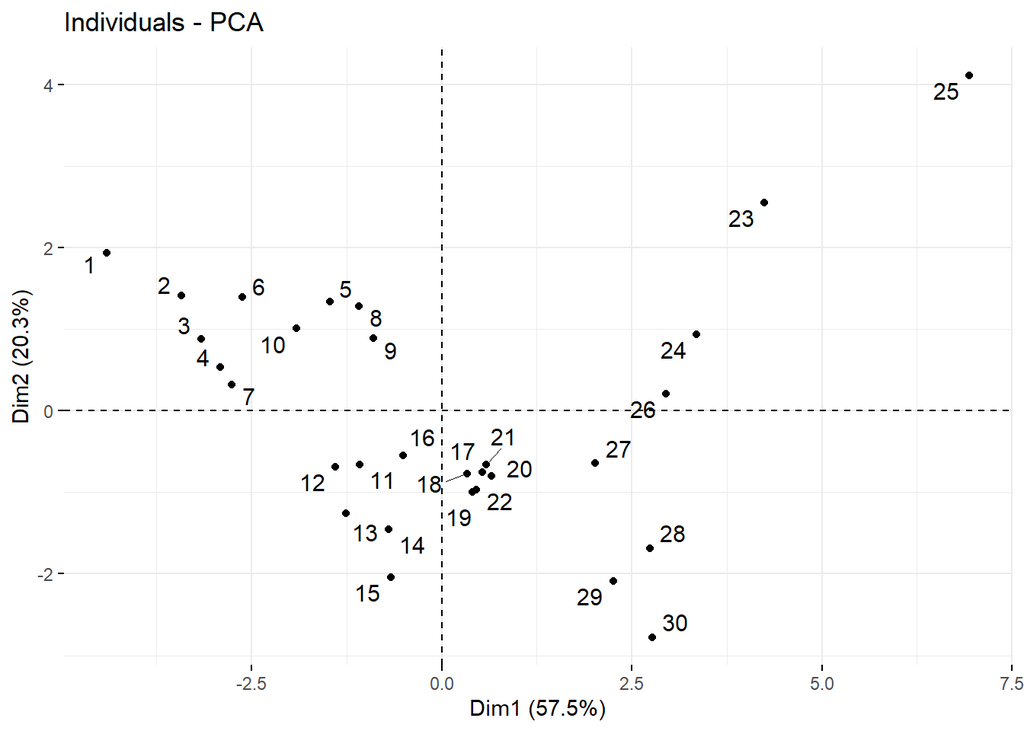

```r
fviz_pca_ind(vars_pca,
             repel = TRUE)
```

##### Calidad de representación de los sitios

```r
vars_pca$ind$cos2
```

```
##         Dim.1      Dim.2        Dim.3        Dim.4        Dim.5
## 1  0.70848603 0.13637518 3.338827e-02 6.483598e-02 2.894632e-04
## 2  0.69610774 0.11891955 1.300452e-03 2.774262e-02 1.382917e-01
## 3  0.67867729 0.05288958 1.925306e-01 9.896770e-03 4.860910e-02
## 4  0.92172124 0.03094718 1.642002e-04 1.074844e-04 2.526588e-05
## 5  0.35931749 0.29797006 9.519158e-02 2.303267e-01 2.540226e-05
## 6  0.69767912 0.19775653 2.159060e-02 1.527754e-03 3.890034e-02
## 7  0.82566074 0.01119645 1.009894e-02 1.776918e-02 1.021394e-01
## 8  0.16447367 0.22915856 6.161299e-02 5.115734e-01 7.054393e-03
## 9  0.18061071 0.17772783 4.707146e-03 4.991515e-01 1.538087e-02
## 10 0.38061565 0.10561556 4.594766e-01 4.476452e-03 3.384105e-02
## 11 0.35207280 0.13333529 8.480690e-05 2.507569e-02 4.099094e-01
## 12 0.45507334 0.10960697 2.055582e-01 4.275390e-03 4.762515e-02
## 13 0.34724108 0.34921707 1.200378e-06 4.184690e-08 2.678310e-01
## 14 0.09192503 0.40329941 2.891242e-01 3.763397e-03 1.817779e-01
```

[output cut: 16 more lines]

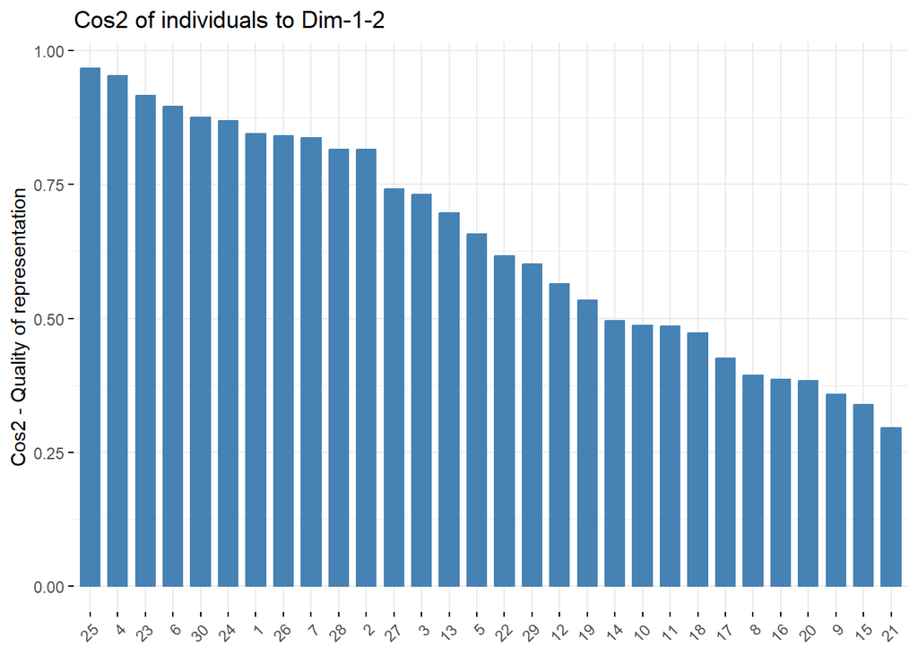

```r
fviz_cos2(vars_pca,
          choice = "ind", # indicamos que muestre los individuos (sitios)
          axes = 1:2)
```

```r
# por defecto muestra todos los individuos, pero podemos indicar que muestre un número máximo con el argumento `top =`.
```

Gráfico de coordenadas de los sitios basado en la calidad de representación:

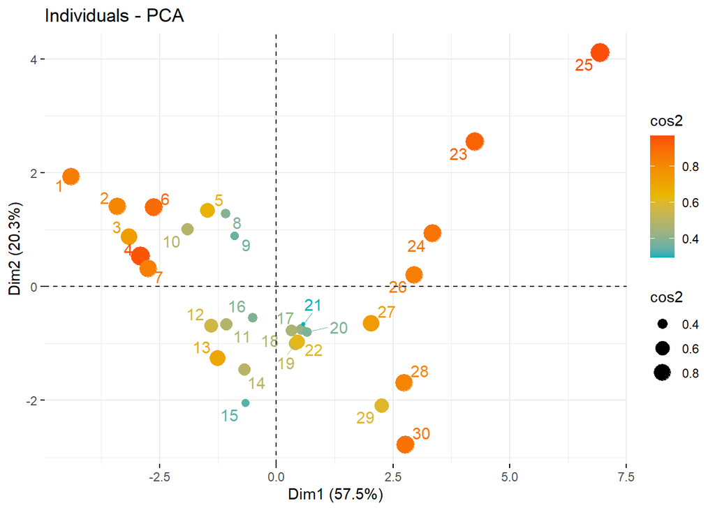

```r
fviz_pca_ind(vars_pca,
             col.ind = "cos2",
             pointsize = "cos2", # para cambiar el tamaño del punto basado en la calidad de representación de cada sitio
             gradient.cols = c("#00AFBB", "#E7B800", "#FC4E07"),
             repel = TRUE)
```

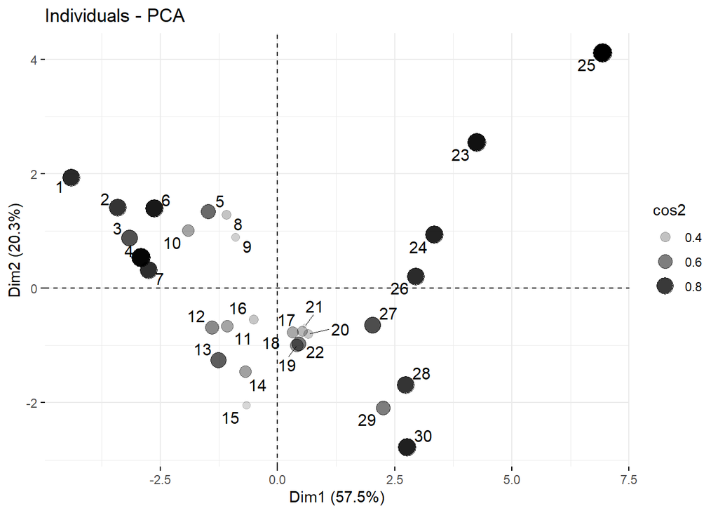

```r
fviz_pca_ind(vars_pca,
             alpha.ind = "cos2",
             pointsize = "cos2",
             repel = TRUE)
```

##### Contribución de los sitios

```r
vars_pca$ind$contrib
```

```
##          Dim.1      Dim.2        Dim.3        Dim.4        Dim.5
## 1  10.21273875  5.5687713 3.029784e+00 1.180037e+01  0.070305529
## 2   6.15941795  2.9807777 7.243764e-02 3.099411e+00 20.617904687
## 3   5.26434655  1.1621558 9.401297e+00 9.692663e-01  6.353074315
## 4   4.48059504  0.4261577 5.024775e-03 6.597052e-03  0.002069453
## 5   1.14243054  2.6837200 1.905271e+00 9.246221e+00  0.001360846
## 6   3.62835585  2.9133865 7.068472e-01 1.003174e-01  3.408730884
## 7   4.00800359  0.1539643 3.086093e-01 1.089086e+00  8.354202518
## 8   0.61938363  2.4446266 1.460637e+00 2.432427e+01  0.447618657
## 9   0.41974629  1.1700702 6.886647e-02 1.464685e+01  0.602295159
## 10  1.92667222  1.5144755 1.464170e+01 2.861037e-01  2.886358055
## 11  0.60909853  0.6534514 9.236194e-04 5.477424e-01 11.948907765
## 12  1.03102548  0.7034598 2.931768e+00 1.223016e-01  1.818065651
## 13  0.83448420  2.3773636 1.815983e-05 1.269752e-06 10.845086285
## 14  0.25296408  3.1438787 5.008599e+00 1.307596e-01  8.428518803
```

[output cut: 16 more lines]

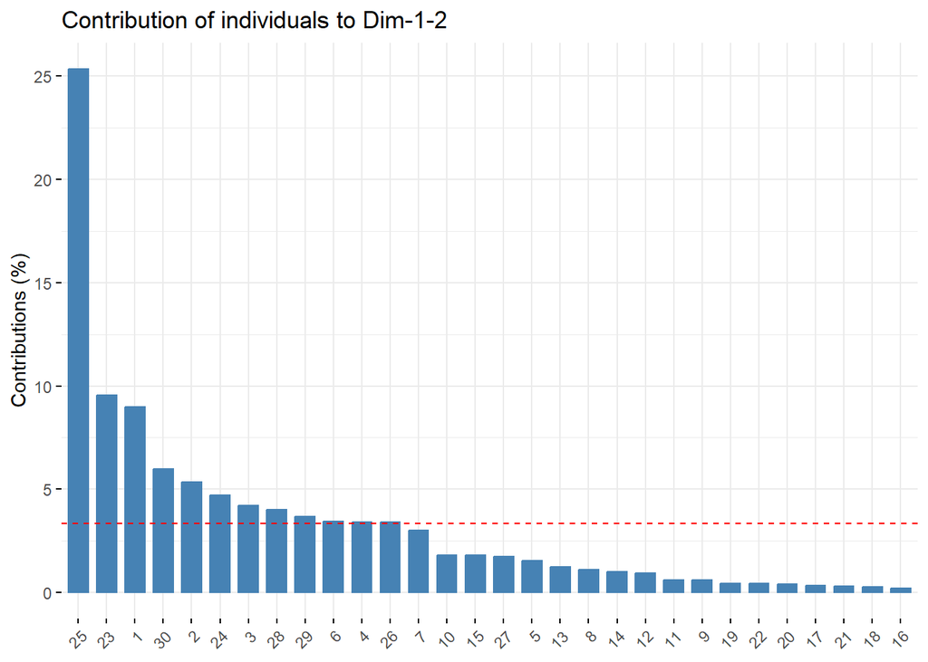

```r
fviz_contrib(vars_pca,
             choice = "ind",
             axes = 1:2)
```

```r
# por defecto muestra todos los individuos, pero podemos indicar que muestre un número máximo con el argumento `top =`.
```

Gráfico de coordenadas de los sitios basado en la contribución de cada sitio:

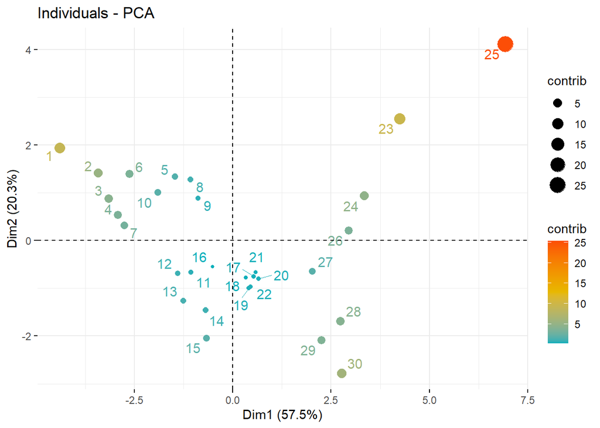

```r
fviz_pca_ind(vars_pca,
             col.ind = "contrib",
             pointsize = "contrib",
             gradient.cols = c("#00AFBB", "#E7B800", "#FC4E07"),
             repel = TRUE)
```

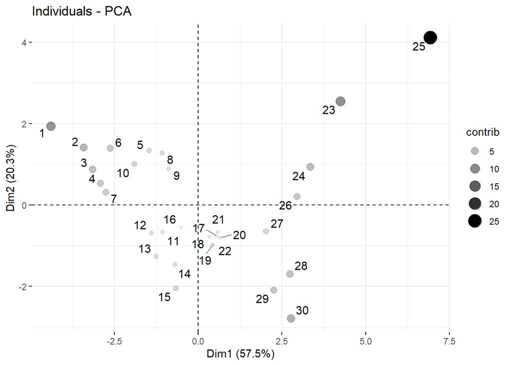

```r
fviz_pca_ind(vars_pca,
             alpha.ind = "contrib",
             pointsize = "contrib",
             repel = TRUE)
```

#### Gráfico de variables y sitios

Podemos generar un gráfico de coordenadas combinado con las variables y los sitios con la función `fviz_pca_biplot()` del paquete `factoextra`:

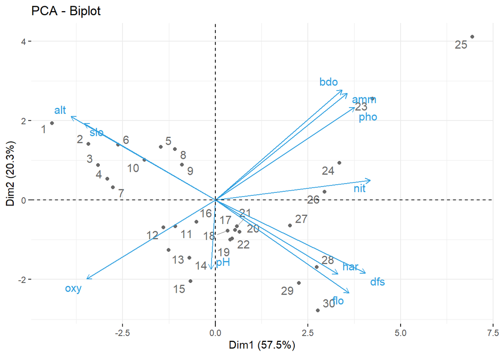

```r
fviz_pca_biplot(vars_pca,
                repel = TRUE,
                col.var = "#2E9FDF", # para indicar el color de las variables
                col.ind = "#696969") # para indicar el color de los sitios
```

Con este biplot podemos interpretar qué variables tienen influencia sobre los diferentes sitios, por ejemplo, los sitios 23 y 25 tienen mayor concentración de fosfatos y de nitrógeno amoniacal, y también tienen una mayor demanda biológica de oxígeno.

Los gráficos de las funciones `fviz_pca_ ... ()` son compatibles con `ggplot2` por lo que podemos modificarlos y exportarlos con la función `ggsave()`:

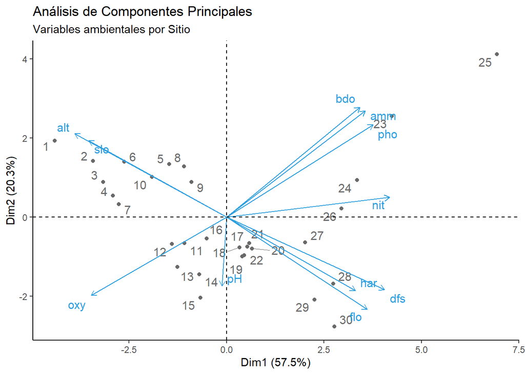

```r
fviz_pca_biplot(vars_pca,
                repel = TRUE,
                col.var = "#2E9FDF",
                col.ind = "#696969") +
  labs(title = "Análisis de Componentes Principales",
       subtitle = "Variables ambientales por Sitio") +
  theme_classic()
```

```r
ggsave("Imagenes/PCA.jpg")

# Recordemos que por defecto se guarda el último gráfico que se desplegó. Pero podemos especificar un gráfico dentro de un objeto con el argumento `plot =`
```

También podemos agregar geometrías para identificar la variabilidad o similitud entre los sitios de acuerdo con una variable categórica.

Por ejemplo, podemos crear una variable de “zona” con base en la altitud de cada sitio de muestreo. Podemos agrupar los sitios ubicados a > 700 msnm en “Zona alta”, los sitios de 400-700 msnm en “Zona media”, y los sitios ubicados a < 400 msnm en “Zona baja”:

```r
vars <- mutate(vars,
               zona = cut(vars$alt,
                          breaks = c(-Inf,
                                     400,
                                     700,
                                     Inf),
                          labels = c("Baja",
                                     "Media",
                                     "Alta")))
head(vars)
```

```
##   dfs alt   slo flo pH har pho nit amm oxy bdo zona
## 1   3 934 6.176  84 79  45   1  20   0 122  27 Alta
## 2  22 932 3.434 100 80  40   2  20  10 103  19 Alta
## 3 102 914 3.638 180 83  52   5  22   5 105  35 Alta
## 4 185 854 3.497 253 80  72  10  21   0 110  13 Alta
## 5 215 849 3.178 264 81  84  38  52  20  80  62 Alta
## 6 324 846 3.497 286 79  60  20  15   0 102  53 Alta
```

Realizamos un PCA con las variables numéricas de la tabla de datos:

```r
PCA2 <- PCA(vars[ ,1:11], graph = FALSE)
```

Generamos el gráfico biplot y agregamos las geometrías:

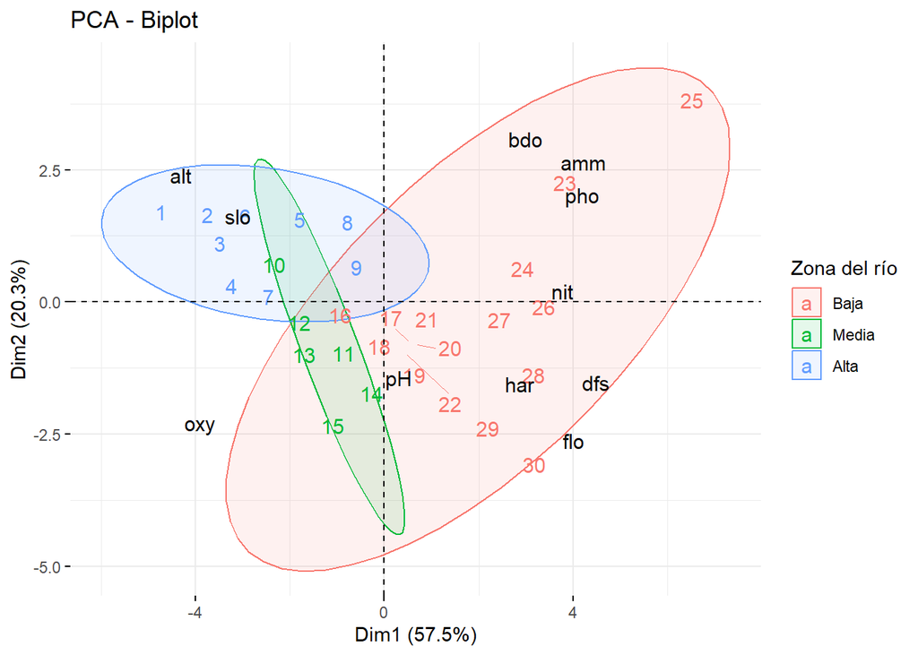

```r
fviz_pca_biplot(PCA2,
                repel = TRUE,
                col.ind = "gray30",
                col.var = "gray3",
                habillage = vars$zona, # indicamos la variable categórica
                addEllipses = TRUE, # agregamos la geometría
                legend.title = "Zona del río",
                geom.ind = "text",
                geom.var = "text")
```

#### Modelo a partir de un PCA

`fish` es otra tabla de datos dentro de `doubs` y contiene la abundancia de 27 especies de peces en cada sitio de muestreo:

```r
abund <- doubs$fish
head(abund)
```

```
##   Cogo Satr Phph Neba Thth Teso Chna Chto Lele Lece Baba Spbi Gogo Eslu Pefl
## 1    0    3    0    0    0    0    0    0    0    0    0    0    0    0    0
## 2    0    5    4    3    0    0    0    0    0    0    0    0    0    0    0
## 3    0    5    5    5    0    0    0    0    0    0    0    0    0    1    0
## 4    0    4    5    5    0    0    0    0    0    1    0    0    1    2    2
## 5    0    2    3    2    0    0    0    0    5    2    0    0    2    4    4
## 6    0    3    4    5    0    0    0    0    1    2    0    0    1    1    1
##   Rham Legi Scer Cyca Titi Abbr Icme Acce Ruru Blbj Alal Anan
## 1    0    0    0    0    0    0    0    0    0    0    0    0
## 2    0    0    0    0    0    0    0    0    0    0    0    0
## 3    0    0    0    0    0    0    0    0    0    0    0    0
## 4    0    0    0    0    1    0    0    0    0    0    0    0
## 5    0    0    2    0    3    0    0    0    5    0    0    0
## 6    0    0    0    0    2    0    0    0    1    0    0    0
```

Podemos agregar los componentes principales que explicaron más del 70% de la variabilidad de los datos a la tabla de abundancia:

```r
abund_CP <- mutate(abund,
                   CP1 = sitios$Dim.1,
                   CP2 = sitios$Dim.2)
```

```r
modelo <- glm(Abbr ~ CP1 + CP2, data = abund_CP, family = poisson)
```

```r
parameters(modelo, exponentiate = TRUE)
```

```
## Parameter   |  IRR |   SE |       95% CI |     z |      p
## ---------------------------------------------------------
## (Intercept) | 0.34 | 0.12 | [0.16, 0.65] | -2.98 | 0.003
## CP1         | 1.53 | 0.19 | [1.21, 1.97] |  3.54 | < .001
## CP2         | 0.52 | 0.07 | [0.38, 0.67] | -4.60 | < .001
```

```
##
## Uncertainty intervals (profile-likelihood) and p-values (two-tailed)
##   computed using a Wald z-distribution approximation.
```

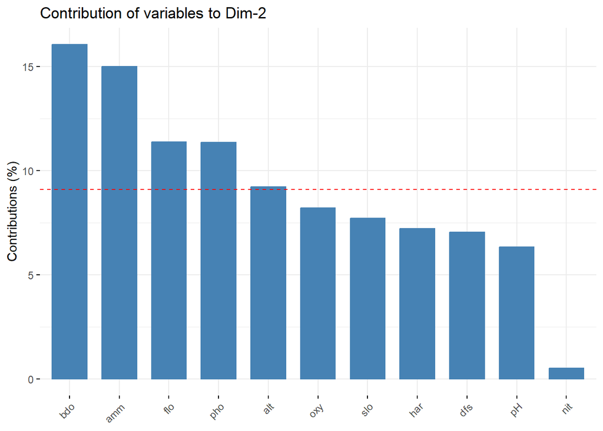

```r
fviz_contrib(PCA2,
             choice = "var",
             axes = 2)
```

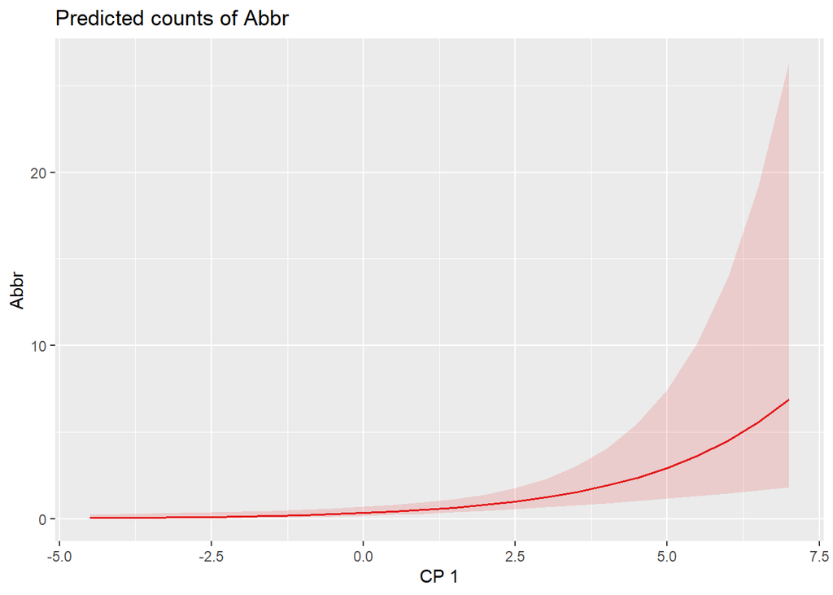

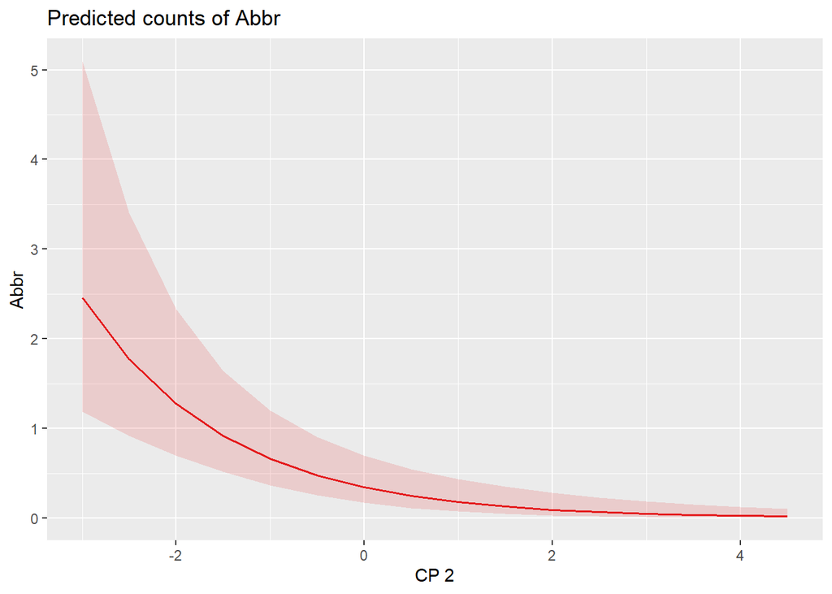

```r
plot_model(modelo, "pred")
```

#### PCA con `parameters`

El paquete `parameters` también cuenta con una función para realizar análisis de componentes principales = `principal_components()`:

```r
pca.parameters <- principal_components(vars,
                                       n = 3) # indicamos el número de CPs que queremos que nos muestre la salida de la función
```

```r
summary(pca.parameters)
```

```
## # (Explained) Variance of Components
##
## Parameter                       |   PC1 |   PC2 |   PC3
## -------------------------------------------------------
## Eigenvalues                     | 6.322 | 2.232 | 1.004
## Variance Explained              | 0.575 | 0.203 | 0.091
## Variance Explained (Cumulative) | 0.575 | 0.778 | 0.869
## Variance Explained (Proportion) | 0.575 | 0.203 | 0.091
```

El `summary()` nos muestra un resumen de los eigenvalues, la varianza explicada y la varianza acumulada explicada por cada componente.

También podemos extraer los CP para las variables:

```r
pca.parameters
```

```
## # Loadings from Principal Component Analysis (no rotation)
##
## Variable |   PC1 |   PC2 |      PC3 | Complexity
## ------------------------------------------------
## dfs      |  0.87 |  0.40 |    -0.16 |       1.48
## alt      | -0.84 | -0.45 |     0.13 |       1.60
## slo      | -0.76 | -0.41 |    -0.21 |       1.73
## flo      |  0.78 |  0.50 |    -0.19 |       1.86
## pH       | -0.02 |  0.38 |     0.91 |       1.33
## har      |  0.71 |  0.40 |    -0.03 |       1.58
## pho      |  0.81 | -0.50 |     0.14 |       1.74
## nit      |  0.90 | -0.11 |     0.01 |       1.03
## amm      |  0.77 | -0.58 |     0.13 |       1.92
## oxy      | -0.75 |  0.43 | 1.22e-03 |       1.59
## bdo      |  0.74 | -0.60 |     0.09 |       1.95
##
## The 3 principal components accounted for 86.89% of the total variance of the original data (PC1 = 57.47%, PC2 = 20.29%, PC3 = 9.13%).
```

Y exportarlo:

```r
export(pca.parameters, "PCA_parameters_variables.csv")
```

Para extraer los CPs para los sitios utilizamos la función `predict()`:

```r
PCA_par_sitios <- predict(pca.parameters)
PCA_par_sitios
```

```
##           PC1        PC2          PC3
## 1  -4.3269756 -1.8983945 -0.939324774
## 2  -3.3603396 -1.3889019  0.145241956
## 3  -3.1066016 -0.8672393  1.654641124
## 4  -2.8660330 -0.5251604 -0.038253241
## 5  -1.4471989 -1.3178785  0.744883450
## 6  -2.5791005 -1.3731115 -0.453704112
## 7  -2.7106746 -0.3156580  0.299788156
## 8  -1.0655975 -1.2578042  0.652200511
## 9  -0.8772165 -0.8701873  0.141616498
## 10 -1.8793915 -0.9900061 -2.064931415
## 11 -1.0567131  0.6502995 -0.016400476
## 12 -1.3748269  0.6747244 -0.924005832
## 13 -1.2368653  1.2403795  0.002299672
## 14 -0.6809932  1.4263945  1.207725087
```

[output cut: 16 more lines]

```r
export(PCA_par_sitios, "PCA_parameters_sitios.csv")
```

Un factor importante para elegir cuántos CPs escoger, aparte de que juntos expliquen el 70% de la varianza acumulada, es si todas las variables están bien representadas en los CPs que escogimos.

Con la función `closest_component()` podemos observar qué variables de los datos originales pertenecen a qué componente extraído:

```r
closest_component(pca.parameters)
```

```
## dfs alt slo flo  pH har pho nit amm oxy bdo
##   1   1   1   1   3   1   1   1   1   1   1
```

Podemos generar un grafico del PCA generado con la función `principal_components()`:

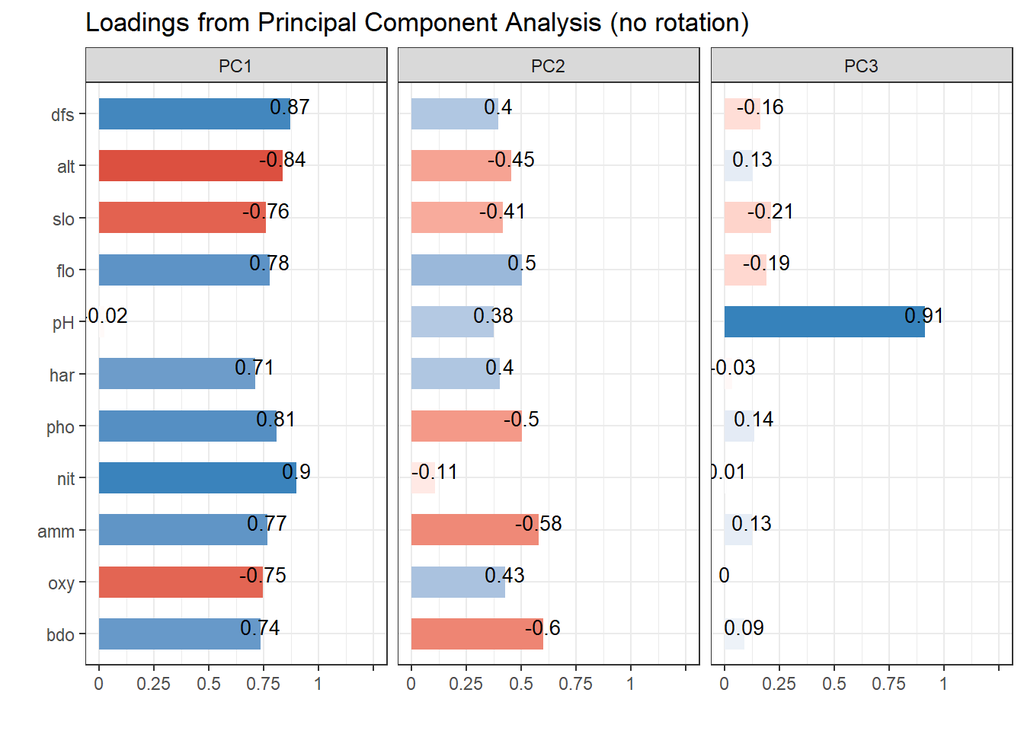

```r
plot(pca.parameters) +
  theme_bw()
```

```r
# Este gráfico nos muestra las coordenadas de cada variable en cada componente y la calidad de la representación.
```